# Module 2

#### Hemi-module gene counts:

127 probesets in hemi-module A.  
105 probesets in hemi-module B.  
Note: While the mapping of probesets to genes is usually one-to-one, some genes are targeted by multiple probesets, some probesets target multiple genes, and some probesets do not target any genes (i.e., the region of the genome they match is no longer considered genic).

#### Contrast SVE:

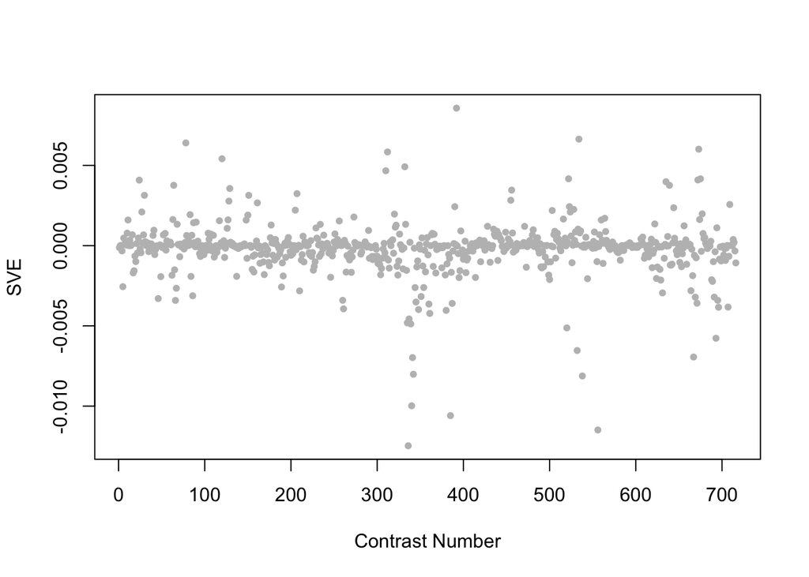

Positive SVE Contrasts:

|  | Contrast.Num | SVE | GEO.GSE | Cond.1 | Cond.2 | Mutation |
| --- | --- | --- | --- | --- | --- | --- |
| GSE32339.s1t2.vs.s0t2 | 392 | 0.01 | GSE32339 | Adult Mutant, biological rep1 | Adult Wild-type, biological rep1 | nep-1 |
| GSE2180.s3t10.vs.s1t10 | 534 | 0.01 | GSE2180 | p186-2 | 186-1 | pie-1(zu154) |
| GSE8004.s2t2.vs.s1t2 | 78 | 0.01 | GSE8004 | Larval Reference, biological rep 1 of set 1 | Larval A-class, biological rep 1 of set 3 |  |
| GSE14640B.s1t1.vs.s0t1 | 673 | 0.01 | GSE14640 | XX_DPY27-N_042807_A | XX_WT-N_080307_A |  |
| GSE41056.s1t2.vs.s1t1 | 312 | 0.01 | GSE41056 | JU1580_inf_1 | JU1580_1 |  |

Negative SVE Contrasts:

|  | Contrast.Num | SVE | GEO.GSE | Cond.1 | Cond.2 | Mutation |
| --- | --- | --- | --- | --- | --- | --- |
| GSE38997.s4t2.vs.s2t2 | 336 | -0.01 | GSE38997 | experiment 4 UVC-exposed samples at 24 h 4u24 | experiment 4 EtBr-exposed samples at 24 h 4e24 |  |
| GSE2180.s4t4.vs.s3t4 | 556 | -0.01 | GSE2180 | pp53-1 | p53-2 |  |
| GSE34026.s3t1.vs.s0t1 | 385 | -0.01 | GSE34026 | N2 exposed to CVD110, biological rep1 | N2 exposed to OP50(E.coli), biological rep1 |  |
| GSE38997.s4t1.vs.s1t1 | 340 | -0.01 | GSE38997 | experiment 4 UVC-exposed samples at 3 h 4u3 | experiment 4 control samples at 3 h 4c3 |  |
| GSE2180.s4t10.vs.s3t10 | 538 | -0.01 | GSE2180 | pp186-1 | p186-2 | pal-1(RNAi) |

$~$

#### Contrast SVE, Up-Regulated Genes Only:

Calculating SVE for up-regulated and down-regulated genes separately may be more informative in many cases than projecting the up- and down- gene sets together. This is due to the fact that the weight distribution of many modules is highly skewed, indicating that only one of the hemi-modules may be biologically meaningful (i.e., a set of genes are strongly correlated by only a few genes (or none) are strongly anti-correlated to that set.)

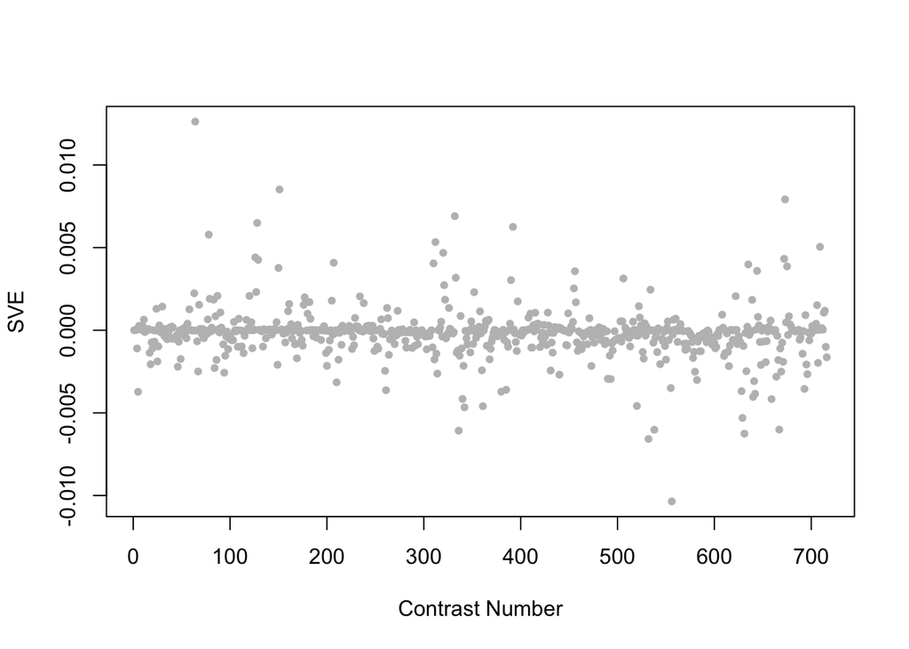

Positive SVE Contrasts:

|  | Contrast.Num | SVE | GEO.GSE | Cond.1 | Cond.2 | Mutation |
| --- | --- | --- | --- | --- | --- | --- |
| GSE8696.s3t1.vs.s1t1 | 64 | 0.01 | GSE8696 | 500 uM hemin (500A) | 4 uM hemin (4A) |  |
| GSE47778.s4t1.vs.s3t1 | 151 | 0.01 | GSE47778 | daf-2;daf-16; replicate 1 | daf-16; replicate 1 | daf-2;daf-16 vs. daf-16 |
| GSE14640B.s1t1.vs.s0t1 | 673 | 0.01 | GSE14640 | XX_DPY27-N_042807_A | XX_WT-N_080307_A |  |
| GSE38997.s2t2.vs.s1t2 | 332 | 0.01 | GSE38997 | experiment 4 EtBr-exposed samples at 24 h 4e24 | experiment 4 control samples at 24 h 4c24 |  |
| GSE54011.s3t1.vs.s0t1 | 128 | 0.01 | GSE54011 | Ce 0.2 mM Se | Ce 0 mM Se |  |

Negative SVE Contrasts:

|  | Contrast.Num | SVE | GEO.GSE | Cond.1 | Cond.2 | Mutation |
| --- | --- | --- | --- | --- | --- | --- |
| GSE2180.s4t4.vs.s3t4 | 556 | -0.01 | GSE2180 | pp53-1 | p53-2 |  |
| GSE2180.s4t9.vs.s3t9 | 532 | -0.01 | GSE2180 | pp143-1 | p143-2 | pal-1(RNAi) |
| GSE19310B.s1t4.vs.s1t1 | 631 | -0.01 | GSE19310 | N2 at 200 for 1 generation, rep1 | N2 at 200 for 15min, rep1 |  |
| GSE38997.s4t2.vs.s2t2 | 336 | -0.01 | GSE38997 | experiment 4 UVC-exposed samples at 24 h 4u24 | experiment 4 EtBr-exposed samples at 24 h 4e24 |  |
| GSE2180.s4t10.vs.s3t10 | 538 | -0.01 | GSE2180 | pp186-1 | p186-2 | pal-1(RNAi) |

$~$

#### Contrast SVE, Down-Regulated Genes Only:

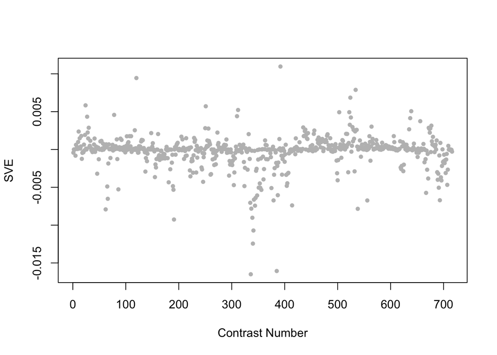

Positive SVE Contrasts:

|  | Contrast.Num | SVE | GEO.GSE | Cond.1 | Cond.2 | Mutation |
| --- | --- | --- | --- | --- | --- | --- |
| GSE32339.s1t2.vs.s0t2 | 392 | 0.01 | GSE32339 | Adult Mutant, biological rep1 | Adult Wild-type, biological rep1 | nep-1 |
| GSE54024.s3t1.vs.s4t1 | 120 | 0.01 | GSE54024 | nuo-6(qm200) young adults, biological rep 1 | isp-1(qm150) young adults, biological rep 1 |  |
| GSE2180.s3t10.vs.s1t10 | 534 | 0.01 | GSE2180 | p186-2 | 186-1 | pie-1(zu154) |
| GSE2180.s3t8.vs.s2t8 | 524 | 0.01 | GSE2180 | p122-2 | ms122-1 |  |
| GSE9665.s3t2.vs.s0t2 | 24 | 0.01 | GSE9665 | mex-3 hlh-1 186 A | mex-3 186 A | hlh-1 |

Negative SVE Contrasts:

|  | Contrast.Num | SVE | GEO.GSE | Cond.1 | Cond.2 | Mutation |
| --- | --- | --- | --- | --- | --- | --- |
| GSE38997.s4t2.vs.s2t2 | 336 | -0.02 | GSE38997 | experiment 4 UVC-exposed samples at 24 h 4u24 | experiment 4 EtBr-exposed samples at 24 h 4e24 |  |
| GSE34026.s3t1.vs.s0t1 | 385 | -0.02 | GSE34026 | N2 exposed to CVD110, biological rep1 | N2 exposed to OP50(E.coli), biological rep1 |  |
| GSE38997.s4t1.vs.s1t1 | 340 | -0.01 | GSE38997 | experiment 4 UVC-exposed samples at 3 h 4u3 | experiment 4 control samples at 3 h 4c3 |  |
| GSE38997.s3t1.vs.s2t1 | 341 | -0.01 | GSE38997 | experiment 4 UVC- and EtBr-exposed samples at 3 h 4eu3 | experiment 4 EtBr-exposed samples at 3 h 4e3 |  |
| GSE46291.s2t2.vs.s2t1 | 191 | -0.01 | GSE46291 | L4-lethargus_rep1 | L3-lethargus_rep1 |  |

$~$

$~$

#### GO Term Enrichment:

This analysis tests each hemi-module for enrichment of specific GO terms. Only gene-level annotations (e.g., as would be found on the gene’s page in Wormbase) are tested - the hierarchical structure of the GO ontology is not taken into account.

*Note: At least the top two most enriched terms from each GO domain (BP/MF/CC) are shown, even when not statistically significant.*

##### Enriched GO terms: Hemi-module A

| ID | GO.Term | GO Domain | Raw p-value | Adj p-value |
| --- | --- | --- | --- | --- |
| [GO_1902473](http://amigo.geneontology.org/amigo/term/GO:1902473) | regulation of protein localization to synapse | BP | 1.37e-04 | 4.99e-01 |
| [GO_0006777](http://amigo.geneontology.org/amigo/term/GO:0006777) | Mo-molybdopterin cofactor biosynthetic process | BP | 1.25e-03 | 9.96e-01 |
| [GO_0046872](http://amigo.geneontology.org/amigo/term/GO:0046872) | metal ion binding | MF | 1.27e-04 | 1.42e-01 |
| [GO_0003700](http://amigo.geneontology.org/amigo/term/GO:0003700) | DNA-binding transcription factor activity | MF | 1.86e-04 | 1.42e-01 |
| [GO_0099572](http://amigo.geneontology.org/amigo/term/GO:0099572) | postsynaptic specialization | CC | 1.36e-02 | 9.97e-01 |
| [GO_0099634](http://amigo.geneontology.org/amigo/term/GO:0099634) | postsynaptic specialization membrane | CC | 1.36e-02 | 9.97e-01 |

##### Enriched GO terms: Hemi-module B

| ID | GO.Term | GO Domain | Raw p-value | Adj p-value |
| --- | --- | --- | --- | --- |
| [GO_0045324](http://amigo.geneontology.org/amigo/term/GO:0045324) | late endosome to vacuole transport | BP | 2.50e-04 | 9.12e-01 |
| [GO_0007127](http://amigo.geneontology.org/amigo/term/GO:0007127) | meiosis I | BP | 5.07e-03 | 9.98e-01 |
| [GO_0061608](http://amigo.geneontology.org/amigo/term/GO:0061608) | nuclear import signal receptor activity | MF | 5.22e-04 | 1.00e+00 |
| [GO_0008139](http://amigo.geneontology.org/amigo/term/GO:0008139) | nuclear localization sequence binding | MF | 1.11e-03 | 1.00e+00 |
| [GO_0002178](http://amigo.geneontology.org/amigo/term/GO:0002178) | palmitoyltransferase complex | CC | 5.07e-03 | 9.99e-01 |
| [GO_0005780](http://amigo.geneontology.org/amigo/term/GO:0005780) | extrinsic component of intraperoxisomal membrane | CC | 5.07e-03 | 9.99e-01 |

$~$

$~$

#### Tissue Enrichment:

This analysis tests each hemi-module for enrichment of genes associated with anatomy terms. Negative enrichment scores indicate fewer hemi-module genes than expected by random chance were associated with the anatomy term in question.

##### Enriched tissues: Hemi-module A

No significant annotations.

##### Enriched tissues: Hemi-module B

No significant annotations.

$~$

$~$

#### HOMER promoter motif enrichment:

This analysis tests each hemi-module for enrichment of 108 known *C. elegans* transcription factor binding site motifs (see [108 CE motifs](https://katiepod.github.io//all.worm.motifs.html)) using the HOMER (Hypergeometric Optimization of Motif EnRichment) software (see [PMID:20513432](https://pubmed.ncbi.nlm.nih.gov/20513432)). HOMER was run using default parameters on sequences 1 kb upstream of the transcription start site.

##### Motif enrichment: Hemi-module A

Total target sequences = 103  
Total background sequences = 41565  
* - possible false positive

Rank

Motif

P-value

log P-pvalue

% of Targets

% of Background

STD(Bg STD)

Best Match/Details

Motif File

1 *

[figure not shown]

1e-11

-2.553e+01

16.50%

1.82%

304.2bp (299.7bp)

PL0017.1_hlh-2::hlh-10/Jaspar(0.644)  
[More Information](https://katiepod.github.io/HomerResults/m2_a_hemi_genes.txt.out.1kb/homerResults/motif1.info.html) | [Similar Motifs Found](https://katiepod.github.io/HomerResults/m2_a_hemi_genes.txt.out.1kb/homerResults/motif1.similar.html)

[motif file (matrix)](https://katiepod.github.io/HomerResults/m2_a_hemi_genes.txt.out.1kb/homerResults/motif1.motif)

2 *

[figure not shown]

1e-10

-2.467e+01

5.83%

0.04%

295.4bp (242.8bp)

fos-1/MA1448.1/Jaspar(0.456)  
[More Information](https://katiepod.github.io/HomerResults/m2_a_hemi_genes.txt.out.1kb/homerResults/motif2.info.html) | [Similar Motifs Found](https://katiepod.github.io/HomerResults/m2_a_hemi_genes.txt.out.1kb/homerResults/motif2.similar.html)

[motif file (matrix)](https://katiepod.github.io/HomerResults/m2_a_hemi_genes.txt.out.1kb/homerResults/motif2.motif)

3 *

[figure not shown]

1e-10

-2.421e+01

36.89%

11.61%

296.0bp (311.5bp)

elt-2/MA1701.1/Jaspar(0.917)  
[More Information](https://katiepod.github.io/HomerResults/m2_a_hemi_genes.txt.out.1kb/homerResults/motif3.info.html) | [Similar Motifs Found](https://katiepod.github.io/HomerResults/m2_a_hemi_genes.txt.out.1kb/homerResults/motif3.similar.html)

[motif file (matrix)](https://katiepod.github.io/HomerResults/m2_a_hemi_genes.txt.out.1kb/homerResults/motif3.motif)

4 *

[figure not shown]

1e-10

-2.381e+01

19.42%

3.04%

299.4bp (310.1bp)

cebp-1/MA1444.1/Jaspar(0.618)  
[More Information](https://katiepod.github.io/HomerResults/m2_a_hemi_genes.txt.out.1kb/homerResults/motif4.info.html) | [Similar Motifs Found](https://katiepod.github.io/HomerResults/m2_a_hemi_genes.txt.out.1kb/homerResults/motif4.similar.html)

[motif file (matrix)](https://katiepod.github.io/HomerResults/m2_a_hemi_genes.txt.out.1kb/homerResults/motif4.motif)

5 *

[figure not shown]

1e-9

-2.297e+01

4.85%

0.02%

313.9bp (277.6bp)

fos-1/MA1448.1/Jaspar(0.660)  
[More Information](https://katiepod.github.io/HomerResults/m2_a_hemi_genes.txt.out.1kb/homerResults/motif5.info.html) | [Similar Motifs Found](https://katiepod.github.io/HomerResults/m2_a_hemi_genes.txt.out.1kb/homerResults/motif5.similar.html)

[motif file (matrix)](https://katiepod.github.io/HomerResults/m2_a_hemi_genes.txt.out.1kb/homerResults/motif5.motif)

6 *

[figure not shown]

1e-9

-2.256e+01

6.80%

0.13%

284.0bp (356.6bp)

POL011.1_XCPE1/Jaspar(0.745)  
[More Information](https://katiepod.github.io/HomerResults/m2_a_hemi_genes.txt.out.1kb/homerResults/motif6.info.html) | [Similar Motifs Found](https://katiepod.github.io/HomerResults/m2_a_hemi_genes.txt.out.1kb/homerResults/motif6.similar.html)

[motif file (matrix)](https://katiepod.github.io/HomerResults/m2_a_hemi_genes.txt.out.1kb/homerResults/motif6.motif)

7 *

[figure not shown]

1e-9

-2.157e+01

5.83%

0.08%

111.2bp (232.6bp)

PL0012.1_hlh-2::hlh-8/Jaspar(0.775)  
[More Information](https://katiepod.github.io/HomerResults/m2_a_hemi_genes.txt.out.1kb/homerResults/motif7.info.html) | [Similar Motifs Found](https://katiepod.github.io/HomerResults/m2_a_hemi_genes.txt.out.1kb/homerResults/motif7.similar.html)

[motif file (matrix)](https://katiepod.github.io/HomerResults/m2_a_hemi_genes.txt.out.1kb/homerResults/motif7.motif)

8 *

[figure not shown]

1e-8

-1.931e+01

5.83%

0.12%

252.1bp (275.1bp)

ceh-22/MA0264.1/Jaspar(0.562)  
[More Information](https://katiepod.github.io/HomerResults/m2_a_hemi_genes.txt.out.1kb/homerResults/motif8.info.html) | [Similar Motifs Found](https://katiepod.github.io/HomerResults/m2_a_hemi_genes.txt.out.1kb/homerResults/motif8.similar.html)

[motif file (matrix)](https://katiepod.github.io/HomerResults/m2_a_hemi_genes.txt.out.1kb/homerResults/motif8.motif)

9 *

[figure not shown]

1e-8

-1.927e+01

8.74%

0.51%

351.1bp (329.3bp)

POL004.1_CCAAT-box/Jaspar(0.601)  
[More Information](https://katiepod.github.io/HomerResults/m2_a_hemi_genes.txt.out.1kb/homerResults/motif9.info.html) | [Similar Motifs Found](https://katiepod.github.io/HomerResults/m2_a_hemi_genes.txt.out.1kb/homerResults/motif9.similar.html)

[motif file (matrix)](https://katiepod.github.io/HomerResults/m2_a_hemi_genes.txt.out.1kb/homerResults/motif9.motif)

10 *

[figure not shown]

1e-8

-1.888e+01

9.71%

0.73%

287.5bp (309.9bp)

sma-4/MA0925.1/Jaspar(0.623)  
[More Information](https://katiepod.github.io/HomerResults/m2_a_hemi_genes.txt.out.1kb/homerResults/motif10.info.html) | [Similar Motifs Found](https://katiepod.github.io/HomerResults/m2_a_hemi_genes.txt.out.1kb/homerResults/motif10.similar.html)

[motif file (matrix)](https://katiepod.github.io/HomerResults/m2_a_hemi_genes.txt.out.1kb/homerResults/motif10.motif)

11 *

[figure not shown]

1e-8

-1.847e+01

18.45%

3.73%

297.6bp (321.5bp)

POL009.1_DCE_S_II/Jaspar(0.619)  
[More Information](https://katiepod.github.io/HomerResults/m2_a_hemi_genes.txt.out.1kb/homerResults/motif11.info.html) | [Similar Motifs Found](https://katiepod.github.io/HomerResults/m2_a_hemi_genes.txt.out.1kb/homerResults/motif11.similar.html)

[motif file (matrix)](https://katiepod.github.io/HomerResults/m2_a_hemi_genes.txt.out.1kb/homerResults/motif11.motif)

12 *

[figure not shown]

1e-7

-1.835e+01

15.53%

2.57%

324.9bp (299.4bp)

CES-1(Homeobox)/cElegans-L1-CES1-ChIP-Seq(modEncode)/Homer(0.551)  
[More Information](https://katiepod.github.io/HomerResults/m2_a_hemi_genes.txt.out.1kb/homerResults/motif12.info.html) | [Similar Motifs Found](https://katiepod.github.io/HomerResults/m2_a_hemi_genes.txt.out.1kb/homerResults/motif12.similar.html)

[motif file (matrix)](https://katiepod.github.io/HomerResults/m2_a_hemi_genes.txt.out.1kb/homerResults/motif12.motif)

13 *

[figure not shown]

1e-7

-1.833e+01

13.59%

1.88%

300.2bp (311.1bp)

ceh-22/MA0264.1/Jaspar(0.524)  
[More Information](https://katiepod.github.io/HomerResults/m2_a_hemi_genes.txt.out.1kb/homerResults/motif13.info.html) | [Similar Motifs Found](https://katiepod.github.io/HomerResults/m2_a_hemi_genes.txt.out.1kb/homerResults/motif13.similar.html)

[motif file (matrix)](https://katiepod.github.io/HomerResults/m2_a_hemi_genes.txt.out.1kb/homerResults/motif13.motif)

14 *

[figure not shown]

1e-7

-1.817e+01

7.77%

0.40%

342.5bp (317.8bp)

lim-4/MA0923.1/Jaspar(0.647)  
[More Information](https://katiepod.github.io/HomerResults/m2_a_hemi_genes.txt.out.1kb/homerResults/motif14.info.html) | [Similar Motifs Found](https://katiepod.github.io/HomerResults/m2_a_hemi_genes.txt.out.1kb/homerResults/motif14.similar.html)

[motif file (matrix)](https://katiepod.github.io/HomerResults/m2_a_hemi_genes.txt.out.1kb/homerResults/motif14.motif)

15 *

[figure not shown]

1e-7

-1.632e+01

17.48%

3.83%

285.6bp (302.0bp)

che-1/MA0260.1/Jaspar(0.709)  
[More Information](https://katiepod.github.io/HomerResults/m2_a_hemi_genes.txt.out.1kb/homerResults/motif15.info.html) | [Similar Motifs Found](https://katiepod.github.io/HomerResults/m2_a_hemi_genes.txt.out.1kb/homerResults/motif15.similar.html)

[motif file (matrix)](https://katiepod.github.io/HomerResults/m2_a_hemi_genes.txt.out.1kb/homerResults/motif15.motif)

16 *

[figure not shown]

1e-7

-1.616e+01

12.62%

1.89%

202.9bp (311.1bp)

SD0003.1_at_AC_acceptor/Jaspar(0.463)  
[More Information](https://katiepod.github.io/HomerResults/m2_a_hemi_genes.txt.out.1kb/homerResults/motif16.info.html) | [Similar Motifs Found](https://katiepod.github.io/HomerResults/m2_a_hemi_genes.txt.out.1kb/homerResults/motif16.similar.html)

[motif file (matrix)](https://katiepod.github.io/HomerResults/m2_a_hemi_genes.txt.out.1kb/homerResults/motif16.motif)

17 *

[figure not shown]

1e-6

-1.571e+01

10.68%

1.32%

285.2bp (291.4bp)

MF0008.1_MADS_class/Jaspar(0.545)  
[More Information](https://katiepod.github.io/HomerResults/m2_a_hemi_genes.txt.out.1kb/homerResults/motif17.info.html) | [Similar Motifs Found](https://katiepod.github.io/HomerResults/m2_a_hemi_genes.txt.out.1kb/homerResults/motif17.similar.html)

[motif file (matrix)](https://katiepod.github.io/HomerResults/m2_a_hemi_genes.txt.out.1kb/homerResults/motif17.motif)

18 *

[figure not shown]

1e-6

-1.431e+01

9.71%

1.21%

292.6bp (315.1bp)

POL008.1_DCE_S_I/Jaspar(0.619)  
[More Information](https://katiepod.github.io/HomerResults/m2_a_hemi_genes.txt.out.1kb/homerResults/motif18.info.html) | [Similar Motifs Found](https://katiepod.github.io/HomerResults/m2_a_hemi_genes.txt.out.1kb/homerResults/motif18.similar.html)

[motif file (matrix)](https://katiepod.github.io/HomerResults/m2_a_hemi_genes.txt.out.1kb/homerResults/motif18.motif)

19 *

[figure not shown]

1e-6

-1.429e+01

7.77%

0.67%

336.3bp (311.9bp)

ceh-38/MA1699.1/Jaspar(0.548)  
[More Information](https://katiepod.github.io/HomerResults/m2_a_hemi_genes.txt.out.1kb/homerResults/motif19.info.html) | [Similar Motifs Found](https://katiepod.github.io/HomerResults/m2_a_hemi_genes.txt.out.1kb/homerResults/motif19.similar.html)

[motif file (matrix)](https://katiepod.github.io/HomerResults/m2_a_hemi_genes.txt.out.1kb/homerResults/motif19.motif)

20 *

[figure not shown]

1e-6

-1.425e+01

17.48%

4.42%

286.3bp (322.0bp)

eor-1/MA0543.1/Jaspar(0.727)  
[More Information](https://katiepod.github.io/HomerResults/m2_a_hemi_genes.txt.out.1kb/homerResults/motif20.info.html) | [Similar Motifs Found](https://katiepod.github.io/HomerResults/m2_a_hemi_genes.txt.out.1kb/homerResults/motif20.similar.html)

[motif file (matrix)](https://katiepod.github.io/HomerResults/m2_a_hemi_genes.txt.out.1kb/homerResults/motif20.motif)

21 *

[figure not shown]

1e-6

-1.402e+01

2.91%

0.01%

268.8bp (326.8bp)

nhr-6/MA1451.1/Jaspar(0.733)  
[More Information](https://katiepod.github.io/HomerResults/m2_a_hemi_genes.txt.out.1kb/homerResults/motif21.info.html) | [Similar Motifs Found](https://katiepod.github.io/HomerResults/m2_a_hemi_genes.txt.out.1kb/homerResults/motif21.similar.html)

[motif file (matrix)](https://katiepod.github.io/HomerResults/m2_a_hemi_genes.txt.out.1kb/homerResults/motif21.motif)

22 *

[figure not shown]

1e-6

-1.393e+01

4.85%

0.16%

280.7bp (286.9bp)

POL013.1_MED-1/Jaspar(0.548)  
[More Information](https://katiepod.github.io/HomerResults/m2_a_hemi_genes.txt.out.1kb/homerResults/motif22.info.html) | [Similar Motifs Found](https://katiepod.github.io/HomerResults/m2_a_hemi_genes.txt.out.1kb/homerResults/motif22.similar.html)

[motif file (matrix)](https://katiepod.github.io/HomerResults/m2_a_hemi_genes.txt.out.1kb/homerResults/motif22.motif)

23 *

[figure not shown]

1e-5

-1.347e+01

5.83%

0.32%

330.0bp (324.8bp)

MF0004.1_Nuclear_Receptor_class/Jaspar(0.691)  
[More Information](https://katiepod.github.io/HomerResults/m2_a_hemi_genes.txt.out.1kb/homerResults/motif23.info.html) | [Similar Motifs Found](https://katiepod.github.io/HomerResults/m2_a_hemi_genes.txt.out.1kb/homerResults/motif23.similar.html)

[motif file (matrix)](https://katiepod.github.io/HomerResults/m2_a_hemi_genes.txt.out.1kb/homerResults/motif23.motif)

24 *

[figure not shown]

1e-5

-1.307e+01

8.74%

1.08%

257.5bp (313.0bp)

mab-3/MA0262.1/Jaspar(0.654)  
[More Information](https://katiepod.github.io/HomerResults/m2_a_hemi_genes.txt.out.1kb/homerResults/motif24.info.html) | [Similar Motifs Found](https://katiepod.github.io/HomerResults/m2_a_hemi_genes.txt.out.1kb/homerResults/motif24.similar.html)

[motif file (matrix)](https://katiepod.github.io/HomerResults/m2_a_hemi_genes.txt.out.1kb/homerResults/motif24.motif)

25 *

[figure not shown]

1e-5

-1.302e+01

18.45%

5.34%

251.2bp (291.2bp)

ceh-48/MA0921.1/Jaspar(0.618)  
[More Information](https://katiepod.github.io/HomerResults/m2_a_hemi_genes.txt.out.1kb/homerResults/motif25.info.html) | [Similar Motifs Found](https://katiepod.github.io/HomerResults/m2_a_hemi_genes.txt.out.1kb/homerResults/motif25.similar.html)

[motif file (matrix)](https://katiepod.github.io/HomerResults/m2_a_hemi_genes.txt.out.1kb/homerResults/motif25.motif)

26 *

[figure not shown]

1e-5

-1.281e+01

9.71%

1.43%

229.5bp (299.0bp)

MF0001.1_ETS_class/Jaspar(0.545)  
[More Information](https://katiepod.github.io/HomerResults/m2_a_hemi_genes.txt.out.1kb/homerResults/motif26.info.html) | [Similar Motifs Found](https://katiepod.github.io/HomerResults/m2_a_hemi_genes.txt.out.1kb/homerResults/motif26.similar.html)

[motif file (matrix)](https://katiepod.github.io/HomerResults/m2_a_hemi_genes.txt.out.1kb/homerResults/motif26.motif)

27 *

[figure not shown]

1e-5

-1.268e+01

10.68%

1.81%

276.8bp (315.8bp)

PL0015.1_hlh-2::hlh-14/Jaspar(0.547)  
[More Information](https://katiepod.github.io/HomerResults/m2_a_hemi_genes.txt.out.1kb/homerResults/motif27.info.html) | [Similar Motifs Found](https://katiepod.github.io/HomerResults/m2_a_hemi_genes.txt.out.1kb/homerResults/motif27.similar.html)

[motif file (matrix)](https://katiepod.github.io/HomerResults/m2_a_hemi_genes.txt.out.1kb/homerResults/motif27.motif)

28 *

[figure not shown]

1e-5

-1.268e+01

4.85%

0.21%

170.1bp (313.9bp)

ceh-10::ttx-3/MA0263.1/Jaspar(0.521)  
[More Information](https://katiepod.github.io/HomerResults/m2_a_hemi_genes.txt.out.1kb/homerResults/motif28.info.html) | [Similar Motifs Found](https://katiepod.github.io/HomerResults/m2_a_hemi_genes.txt.out.1kb/homerResults/motif28.similar.html)

[motif file (matrix)](https://katiepod.github.io/HomerResults/m2_a_hemi_genes.txt.out.1kb/homerResults/motif28.motif)

29 *

[figure not shown]

1e-5

-1.266e+01

2.91%

0.02%

34.4bp (283.7bp)

lin-54/MA1450.1/Jaspar(0.683)  
[More Information](https://katiepod.github.io/HomerResults/m2_a_hemi_genes.txt.out.1kb/homerResults/motif29.info.html) | [Similar Motifs Found](https://katiepod.github.io/HomerResults/m2_a_hemi_genes.txt.out.1kb/homerResults/motif29.similar.html)

[motif file (matrix)](https://katiepod.github.io/HomerResults/m2_a_hemi_genes.txt.out.1kb/homerResults/motif29.motif)

30 *

[figure not shown]

1e-5

-1.240e+01

2.91%

0.03%

385.8bp (163.3bp)

daf-16/MA1446.1/Jaspar(0.553)  
[More Information](https://katiepod.github.io/HomerResults/m2_a_hemi_genes.txt.out.1kb/homerResults/motif30.info.html) | [Similar Motifs Found](https://katiepod.github.io/HomerResults/m2_a_hemi_genes.txt.out.1kb/homerResults/motif30.similar.html)

[motif file (matrix)](https://katiepod.github.io/HomerResults/m2_a_hemi_genes.txt.out.1kb/homerResults/motif30.motif)

31 *

[figure not shown]

1e-4

-1.127e+01

6.80%

0.73%

158.9bp (283.1bp)

unc-86/MA0926.1/Jaspar(0.570)  
[More Information](https://katiepod.github.io/HomerResults/m2_a_hemi_genes.txt.out.1kb/homerResults/motif31.info.html) | [Similar Motifs Found](https://katiepod.github.io/HomerResults/m2_a_hemi_genes.txt.out.1kb/homerResults/motif31.similar.html)

[motif file (matrix)](https://katiepod.github.io/HomerResults/m2_a_hemi_genes.txt.out.1kb/homerResults/motif31.motif)

32 *

[figure not shown]

1e-4

-9.494e+00

5.83%

0.66%

228.1bp (315.8bp)

POL010.1_DCE_S_III/Jaspar(0.536)  
[More Information](https://katiepod.github.io/HomerResults/m2_a_hemi_genes.txt.out.1kb/homerResults/motif32.info.html) | [Similar Motifs Found](https://katiepod.github.io/HomerResults/m2_a_hemi_genes.txt.out.1kb/homerResults/motif32.similar.html)

[motif file (matrix)](https://katiepod.github.io/HomerResults/m2_a_hemi_genes.txt.out.1kb/homerResults/motif32.motif)

33 *

[figure not shown]

1e-3

-8.972e+00

16.50%

5.95%

271.1bp (309.2bp)

POL004.1_CCAAT-box/Jaspar(0.664)  
[More Information](https://katiepod.github.io/HomerResults/m2_a_hemi_genes.txt.out.1kb/homerResults/motif33.info.html) | [Similar Motifs Found](https://katiepod.github.io/HomerResults/m2_a_hemi_genes.txt.out.1kb/homerResults/motif33.similar.html)

[motif file (matrix)](https://katiepod.github.io/HomerResults/m2_a_hemi_genes.txt.out.1kb/homerResults/motif33.motif)

34 *

[figure not shown]

1e-3

-7.787e+00

6.80%

1.29%

271.0bp (309.1bp)

ceh-38/MA1699.1/Jaspar(0.588)  
[More Information](https://katiepod.github.io/HomerResults/m2_a_hemi_genes.txt.out.1kb/homerResults/motif34.info.html) | [Similar Motifs Found](https://katiepod.github.io/HomerResults/m2_a_hemi_genes.txt.out.1kb/homerResults/motif34.similar.html)

[motif file (matrix)](https://katiepod.github.io/HomerResults/m2_a_hemi_genes.txt.out.1kb/homerResults/motif34.motif)

35 *

[figure not shown]

1e-2

-6.636e+00

30.10%

17.57%

262.4bp (312.9bp)

che-1/MA0260.1/Jaspar(0.577)  
[More Information](https://katiepod.github.io/HomerResults/m2_a_hemi_genes.txt.out.1kb/homerResults/motif35.info.html) | [Similar Motifs Found](https://katiepod.github.io/HomerResults/m2_a_hemi_genes.txt.out.1kb/homerResults/motif35.similar.html)

[motif file (matrix)](https://katiepod.github.io/HomerResults/m2_a_hemi_genes.txt.out.1kb/homerResults/motif35.motif)

36 *

[figure not shown]

1e-2

-4.733e+00

11.65%

5.32%

267.2bp (317.3bp)

snpc-4/MA0544.1/Jaspar(0.824)  
[More Information](https://katiepod.github.io/HomerResults/m2_a_hemi_genes.txt.out.1kb/homerResults/motif36.info.html) | [Similar Motifs Found](https://katiepod.github.io/HomerResults/m2_a_hemi_genes.txt.out.1kb/homerResults/motif36.similar.html)

[motif file (matrix)](https://katiepod.github.io/HomerResults/m2_a_hemi_genes.txt.out.1kb/homerResults/motif36.motif)

##### Motif enrichment: Hemi-module B

Total target sequences = 86  
Total background sequences = 39476  
* - possible false positive

Rank

Motif

P-value

log P-pvalue

% of Targets

% of Background

STD(Bg STD)

Best Match/Details

Motif File

1 *

[figure not shown]

1e-9

-2.263e+01

9.30%

0.27%

262.5bp (313.5bp)

LIN-39(Homeobox)/cElegans.L3-LIN39-ChIP-Seq(modEncode)/Homer(0.663)  
[More Information](https://katiepod.github.io/HomerResults/m2_b_hemi_genes.txt.out.1kb/homerResults/motif1.info.html) | [Similar Motifs Found](https://katiepod.github.io/HomerResults/m2_b_hemi_genes.txt.out.1kb/homerResults/motif1.similar.html)

[motif file (matrix)](https://katiepod.github.io/HomerResults/m2_b_hemi_genes.txt.out.1kb/homerResults/motif1.motif)

2 *

[figure not shown]

1e-9

-2.251e+01

10.47%

0.42%

240.0bp (332.0bp)

MF0002.1_bZIP_CREB/G-box-like_subclass/Jaspar(0.623)  
[More Information](https://katiepod.github.io/HomerResults/m2_b_hemi_genes.txt.out.1kb/homerResults/motif2.info.html) | [Similar Motifs Found](https://katiepod.github.io/HomerResults/m2_b_hemi_genes.txt.out.1kb/homerResults/motif2.similar.html)

[motif file (matrix)](https://katiepod.github.io/HomerResults/m2_b_hemi_genes.txt.out.1kb/homerResults/motif2.motif)

3 *

[figure not shown]

1e-9

-2.251e+01

10.47%

0.42%

218.4bp (306.7bp)

ceh-28/MA1445.1/Jaspar(0.705)  
[More Information](https://katiepod.github.io/HomerResults/m2_b_hemi_genes.txt.out.1kb/homerResults/motif3.info.html) | [Similar Motifs Found](https://katiepod.github.io/HomerResults/m2_b_hemi_genes.txt.out.1kb/homerResults/motif3.similar.html)

[motif file (matrix)](https://katiepod.github.io/HomerResults/m2_b_hemi_genes.txt.out.1kb/homerResults/motif3.motif)

4 *

[figure not shown]

1e-9

-2.145e+01

11.63%

0.67%

193.9bp (308.4bp)

elt-3/MA0542.1/Jaspar(0.586)  
[More Information](https://katiepod.github.io/HomerResults/m2_b_hemi_genes.txt.out.1kb/homerResults/motif4.info.html) | [Similar Motifs Found](https://katiepod.github.io/HomerResults/m2_b_hemi_genes.txt.out.1kb/homerResults/motif4.similar.html)

[motif file (matrix)](https://katiepod.github.io/HomerResults/m2_b_hemi_genes.txt.out.1kb/homerResults/motif4.motif)

5 *

[figure not shown]

1e-8

-2.036e+01

15.12%

1.60%

299.0bp (317.9bp)

eor-1/MA0543.1/Jaspar(0.573)  
[More Information](https://katiepod.github.io/HomerResults/m2_b_hemi_genes.txt.out.1kb/homerResults/motif5.info.html) | [Similar Motifs Found](https://katiepod.github.io/HomerResults/m2_b_hemi_genes.txt.out.1kb/homerResults/motif5.similar.html)

[motif file (matrix)](https://katiepod.github.io/HomerResults/m2_b_hemi_genes.txt.out.1kb/homerResults/motif5.motif)

6 *

[figure not shown]

1e-8

-2.016e+01

5.81%

0.05%

246.2bp (338.3bp)

ceh-48/MA0921.1/Jaspar(0.644)  
[More Information](https://katiepod.github.io/HomerResults/m2_b_hemi_genes.txt.out.1kb/homerResults/motif6.info.html) | [Similar Motifs Found](https://katiepod.github.io/HomerResults/m2_b_hemi_genes.txt.out.1kb/homerResults/motif6.similar.html)

[motif file (matrix)](https://katiepod.github.io/HomerResults/m2_b_hemi_genes.txt.out.1kb/homerResults/motif6.motif)

7 *

[figure not shown]

1e-8

-1.981e+01

13.95%

1.35%

298.0bp (313.5bp)

lin-14/MA0261.1/Jaspar(0.648)  
[More Information](https://katiepod.github.io/HomerResults/m2_b_hemi_genes.txt.out.1kb/homerResults/motif7.info.html) | [Similar Motifs Found](https://katiepod.github.io/HomerResults/m2_b_hemi_genes.txt.out.1kb/homerResults/motif7.similar.html)

[motif file (matrix)](https://katiepod.github.io/HomerResults/m2_b_hemi_genes.txt.out.1kb/homerResults/motif7.motif)

8 *

[figure not shown]

1e-8

-1.935e+01

13.95%

1.41%

261.2bp (309.3bp)

POL004.1_CCAAT-box/Jaspar(0.579)  
[More Information](https://katiepod.github.io/HomerResults/m2_b_hemi_genes.txt.out.1kb/homerResults/motif8.info.html) | [Similar Motifs Found](https://katiepod.github.io/HomerResults/m2_b_hemi_genes.txt.out.1kb/homerResults/motif8.similar.html)

[motif file (matrix)](https://katiepod.github.io/HomerResults/m2_b_hemi_genes.txt.out.1kb/homerResults/motif8.motif)

9 *

[figure not shown]

1e-8

-1.904e+01

10.47%

0.63%

213.2bp (320.0bp)

elt-2/MA1701.1/Jaspar(0.722)  
[More Information](https://katiepod.github.io/HomerResults/m2_b_hemi_genes.txt.out.1kb/homerResults/motif9.info.html) | [Similar Motifs Found](https://katiepod.github.io/HomerResults/m2_b_hemi_genes.txt.out.1kb/homerResults/motif9.similar.html)

[motif file (matrix)](https://katiepod.github.io/HomerResults/m2_b_hemi_genes.txt.out.1kb/homerResults/motif9.motif)

10 *

[figure not shown]

1e-8

-1.888e+01

15.12%

1.81%

271.4bp (294.8bp)

POL005.1_DPE/Jaspar(0.511)  
[More Information](https://katiepod.github.io/HomerResults/m2_b_hemi_genes.txt.out.1kb/homerResults/motif10.info.html) | [Similar Motifs Found](https://katiepod.github.io/HomerResults/m2_b_hemi_genes.txt.out.1kb/homerResults/motif10.similar.html)

[motif file (matrix)](https://katiepod.github.io/HomerResults/m2_b_hemi_genes.txt.out.1kb/homerResults/motif10.motif)

11 *

[figure not shown]

1e-8

-1.881e+01

10.47%

0.65%

253.0bp (297.6bp)

PHA-4(Forkhead)/cElegans-Embryos-PHA4-ChIP-Seq(modEncode)/Homer(0.579)  
[More Information](https://katiepod.github.io/HomerResults/m2_b_hemi_genes.txt.out.1kb/homerResults/motif11.info.html) | [Similar Motifs Found](https://katiepod.github.io/HomerResults/m2_b_hemi_genes.txt.out.1kb/homerResults/motif11.similar.html)

[motif file (matrix)](https://katiepod.github.io/HomerResults/m2_b_hemi_genes.txt.out.1kb/homerResults/motif11.motif)

12 *

[figure not shown]

1e-7

-1.782e+01

6.98%

0.18%

291.3bp (310.4bp)

DPL-1(E2F)/cElegans-Adult-ChIP-Seq(modEncode)/Homer(0.585)  
[More Information](https://katiepod.github.io/HomerResults/m2_b_hemi_genes.txt.out.1kb/homerResults/motif12.info.html) | [Similar Motifs Found](https://katiepod.github.io/HomerResults/m2_b_hemi_genes.txt.out.1kb/homerResults/motif12.similar.html)

[motif file (matrix)](https://katiepod.github.io/HomerResults/m2_b_hemi_genes.txt.out.1kb/homerResults/motif12.motif)

13 *

[figure not shown]

1e-7

-1.772e+01

5.81%

0.08%

139.1bp (239.9bp)

unc-30/MA1443.1/Jaspar(0.591)  
[More Information](https://katiepod.github.io/HomerResults/m2_b_hemi_genes.txt.out.1kb/homerResults/motif13.info.html) | [Similar Motifs Found](https://katiepod.github.io/HomerResults/m2_b_hemi_genes.txt.out.1kb/homerResults/motif13.similar.html)

[motif file (matrix)](https://katiepod.github.io/HomerResults/m2_b_hemi_genes.txt.out.1kb/homerResults/motif13.motif)

14 *

[figure not shown]

1e-7

-1.747e+01

13.95%

1.68%

300.7bp (294.6bp)

MF0011.1_HMG_class/Jaspar(0.556)  
[More Information](https://katiepod.github.io/HomerResults/m2_b_hemi_genes.txt.out.1kb/homerResults/motif14.info.html) | [Similar Motifs Found](https://katiepod.github.io/HomerResults/m2_b_hemi_genes.txt.out.1kb/homerResults/motif14.similar.html)

[motif file (matrix)](https://katiepod.github.io/HomerResults/m2_b_hemi_genes.txt.out.1kb/homerResults/motif14.motif)

15 *

[figure not shown]

1e-7

-1.723e+01

11.63%

1.06%

242.2bp (284.2bp)

POL010.1_DCE_S_III/Jaspar(0.603)  
[More Information](https://katiepod.github.io/HomerResults/m2_b_hemi_genes.txt.out.1kb/homerResults/motif15.info.html) | [Similar Motifs Found](https://katiepod.github.io/HomerResults/m2_b_hemi_genes.txt.out.1kb/homerResults/motif15.similar.html)

[motif file (matrix)](https://katiepod.github.io/HomerResults/m2_b_hemi_genes.txt.out.1kb/homerResults/motif15.motif)

16 *

[figure not shown]

1e-7

-1.715e+01

9.30%

0.55%

235.7bp (295.8bp)

POL010.1_DCE_S_III/Jaspar(0.513)  
[More Information](https://katiepod.github.io/HomerResults/m2_b_hemi_genes.txt.out.1kb/homerResults/motif16.info.html) | [Similar Motifs Found](https://katiepod.github.io/HomerResults/m2_b_hemi_genes.txt.out.1kb/homerResults/motif16.similar.html)

[motif file (matrix)](https://katiepod.github.io/HomerResults/m2_b_hemi_genes.txt.out.1kb/homerResults/motif16.motif)

17 *

[figure not shown]

1e-7

-1.656e+01

9.30%

0.60%

222.8bp (303.6bp)

MF0003.1_REL_class/Jaspar(0.604)  
[More Information](https://katiepod.github.io/HomerResults/m2_b_hemi_genes.txt.out.1kb/homerResults/motif17.info.html) | [Similar Motifs Found](https://katiepod.github.io/HomerResults/m2_b_hemi_genes.txt.out.1kb/homerResults/motif17.similar.html)

[motif file (matrix)](https://katiepod.github.io/HomerResults/m2_b_hemi_genes.txt.out.1kb/homerResults/motif17.motif)

18 *

[figure not shown]

1e-7

-1.634e+01

8.14%

0.40%

300.8bp (314.8bp)

POL010.1_DCE_S_III/Jaspar(0.616)  
[More Information](https://katiepod.github.io/HomerResults/m2_b_hemi_genes.txt.out.1kb/homerResults/motif18.info.html) | [Similar Motifs Found](https://katiepod.github.io/HomerResults/m2_b_hemi_genes.txt.out.1kb/homerResults/motif18.similar.html)

[motif file (matrix)](https://katiepod.github.io/HomerResults/m2_b_hemi_genes.txt.out.1kb/homerResults/motif18.motif)

19 *

[figure not shown]

1e-7

-1.628e+01

11.63%

1.17%

246.5bp (297.4bp)

fkh-2/MA0920.1/Jaspar(0.585)  
[More Information](https://katiepod.github.io/HomerResults/m2_b_hemi_genes.txt.out.1kb/homerResults/motif19.info.html) | [Similar Motifs Found](https://katiepod.github.io/HomerResults/m2_b_hemi_genes.txt.out.1kb/homerResults/motif19.similar.html)

[motif file (matrix)](https://katiepod.github.io/HomerResults/m2_b_hemi_genes.txt.out.1kb/homerResults/motif19.motif)

20 *

[figure not shown]

1e-6

-1.515e+01

12.79%

1.69%

272.5bp (304.6bp)

cebp-1/MA1444.1/Jaspar(0.603)  
[More Information](https://katiepod.github.io/HomerResults/m2_b_hemi_genes.txt.out.1kb/homerResults/motif20.info.html) | [Similar Motifs Found](https://katiepod.github.io/HomerResults/m2_b_hemi_genes.txt.out.1kb/homerResults/motif20.similar.html)

[motif file (matrix)](https://katiepod.github.io/HomerResults/m2_b_hemi_genes.txt.out.1kb/homerResults/motif20.motif)

21 *

[figure not shown]

1e-6

-1.463e+01

19.77%

4.66%

283.5bp (321.0bp)

ceh-48/MA0921.1/Jaspar(0.590)  
[More Information](https://katiepod.github.io/HomerResults/m2_b_hemi_genes.txt.out.1kb/homerResults/motif21.info.html) | [Similar Motifs Found](https://katiepod.github.io/HomerResults/m2_b_hemi_genes.txt.out.1kb/homerResults/motif21.similar.html)

[motif file (matrix)](https://katiepod.github.io/HomerResults/m2_b_hemi_genes.txt.out.1kb/homerResults/motif21.motif)

22 *

[figure not shown]

1e-5

-1.353e+01

15.12%

2.91%

235.9bp (303.0bp)

sma-4/MA0925.1/Jaspar(0.816)  
[More Information](https://katiepod.github.io/HomerResults/m2_b_hemi_genes.txt.out.1kb/homerResults/motif22.info.html) | [Similar Motifs Found](https://katiepod.github.io/HomerResults/m2_b_hemi_genes.txt.out.1kb/homerResults/motif22.similar.html)

[motif file (matrix)](https://katiepod.github.io/HomerResults/m2_b_hemi_genes.txt.out.1kb/homerResults/motif22.motif)

23 *

[figure not shown]

1e-5

-1.280e+01

3.49%

0.03%

204.3bp (213.2bp)

POL012.1_TATA-Box/Jaspar(0.584)  
[More Information](https://katiepod.github.io/HomerResults/m2_b_hemi_genes.txt.out.1kb/homerResults/motif23.info.html) | [Similar Motifs Found](https://katiepod.github.io/HomerResults/m2_b_hemi_genes.txt.out.1kb/homerResults/motif23.similar.html)

[motif file (matrix)](https://katiepod.github.io/HomerResults/m2_b_hemi_genes.txt.out.1kb/homerResults/motif23.motif)

24 *

[figure not shown]

1e-5

-1.251e+01

6.98%

0.46%

228.4bp (277.8bp)

POL010.1_DCE_S_III/Jaspar(0.575)  
[More Information](https://katiepod.github.io/HomerResults/m2_b_hemi_genes.txt.out.1kb/homerResults/motif24.info.html) | [Similar Motifs Found](https://katiepod.github.io/HomerResults/m2_b_hemi_genes.txt.out.1kb/homerResults/motif24.similar.html)

[motif file (matrix)](https://katiepod.github.io/HomerResults/m2_b_hemi_genes.txt.out.1kb/homerResults/motif24.motif)

25 *

[figure not shown]

1e-5

-1.167e+01

4.65%

0.14%

262.3bp (292.9bp)

POL013.1_MED-1/Jaspar(0.570)  
[More Information](https://katiepod.github.io/HomerResults/m2_b_hemi_genes.txt.out.1kb/homerResults/motif25.info.html) | [Similar Motifs Found](https://katiepod.github.io/HomerResults/m2_b_hemi_genes.txt.out.1kb/homerResults/motif25.similar.html)

[motif file (matrix)](https://katiepod.github.io/HomerResults/m2_b_hemi_genes.txt.out.1kb/homerResults/motif25.motif)

26 *

[figure not shown]

1e-3

-8.575e+00

5.81%

0.60%

207.8bp (272.5bp)

mab-3/MA0262.1/Jaspar(0.573)  
[More Information](https://katiepod.github.io/HomerResults/m2_b_hemi_genes.txt.out.1kb/homerResults/motif26.info.html) | [Similar Motifs Found](https://katiepod.github.io/HomerResults/m2_b_hemi_genes.txt.out.1kb/homerResults/motif26.similar.html)

[motif file (matrix)](https://katiepod.github.io/HomerResults/m2_b_hemi_genes.txt.out.1kb/homerResults/motif26.motif)

27 *

[figure not shown]

1e-3

-7.286e+00

10.47%

2.78%

322.4bp (298.7bp)

efl-1/MA0541.1/Jaspar(0.613)  
[More Information](https://katiepod.github.io/HomerResults/m2_b_hemi_genes.txt.out.1kb/homerResults/motif27.info.html) | [Similar Motifs Found](https://katiepod.github.io/HomerResults/m2_b_hemi_genes.txt.out.1kb/homerResults/motif27.similar.html)

[motif file (matrix)](https://katiepod.github.io/HomerResults/m2_b_hemi_genes.txt.out.1kb/homerResults/motif27.motif)

$~$

$~$

#### Promoter Word Enrichment:

This analysis tests each hemi-module for enrichment of specific promoter words. The list of promoter words tested was generated by running the MobyDick algorithm (see [PMID:10944202](https://pubmed.ncbi.nlm.nih.gov/10944202)) on the full set of *C. elegans* 2 Kbp promoters.

##### Enriched promoter words: Hemi-module A

| Word | RC | Raw.p.value | Adj.p.value |
| --- | --- | --- | --- |
| TTTTGCA | TGCAAAA | 1.36e-06 | 7.10e-03 |

##### Enriched promoter words: Hemi-module B

No significant words.

$~$

$~$

#### Promoter Word Depletion:

This analysis tests each hemi-module for depletion (under-enrichment) of specific promoter words. The list of promoter words tested was generated by running the MobyDick algorithm (see [PMID:10944202](https://pubmed.ncbi.nlm.nih.gov/10944202)) on the full set of *C. elegans* 2 Kbp promoters.

##### Depleted promoter words: Hemi-module A

No significant words.

##### Depleted promoter words: Hemi-module B

No significant words.

$~$

$~$

#### 3’-UTR Word Enrichment:

This analysis tests each hemi-module for enrichment of specific 3’-UTR words. The list of words tested was generated by running the MobyDick algorithm (see [PMID:10944202](https://pubmed.ncbi.nlm.nih.gov/10944202)) on the full set of *C. elegans* 3’-UTR sequences.

##### 3’-UTR words: Hemi-module A

No significant words.

##### 3’-UTR words: Hemi-module B

No significant words.

$~$

$~$

#### Hemi-module A genes

| affy_c_elegans | ensembl_gene_id | external_gene_name | module_weight | chromosome_name | strand | start_position | end_position |
| --- | --- | --- | --- | --- | --- | --- | --- |
| 173033_at | WBGene00008396 | D1086.9 | 6.43 | V | 1 | 14104270 | 14106416 |
| 176529_at | WBGene00004878 | smf-3 | 5.96 | IV | 1 | 2619875 | 2625438 |
| 186298_at | WBGene00012525 | Y32B12C.1 | 5.30 | V | 1 | 16606619 | 16608194 |
| 185178_at | WBGene00017203 | F07C4.10 | 4.99 | V | -1 | 7638944 | 7639869 |
| 177846_at | WBGene00008483 | E04D5.4 | 4.94 | II | 1 | 10440286 | 10442515 |
| 182772_at | WBGene00018614 | pals-31 | 4.73 | V | 1 | 636587 | 637501 |
| 188930_at | WBGene00020394 | T10B5.8 | 4.71 | V | 1 | 1842044 | 1844807 |
| 188799_at | WBGene00005616 | srj-29 | 4.68 | V | 1 | 16075659 | 16077308 |
| 185185_at | WBGene00019113 | F59E11.7 | 4.44 | V | 1 | 8990244 | 8991664 |
| 186996_at | WBGene00022267 | Y73C8C.10 | 4.44 | V | -1 | 3125566 | 3127770 |
| 189494_at | WBGene00021412 | cyp-29A3 | 4.39 | V | 1 | 59239 | 63509 |
| 179852_at | WBGene00009426 | F35E12.2 | 4.38 | V | -1 | 13722254 | 13724881 |
| 189870_at | WBGene00021731 | Y49G5A.1 | 4.22 | V | -1 | 5286407 | 5287360 |
| 179003_at | WBGene00009751 | F46A8.8 | 4.20 | I | -1 | 11235882 | 11236707 |
| 183536_at | WBGene00021159 | Y4C6B.5 | 4.19 | IV | 1 | 5319253 | 5325033 |
| 177671_at | WBGene00010528 | K03D3.2 | 4.17 | IV | -1 | 16328135 | 16328614 |
| 176289_s_at | WBGene00004782 | set-2 | 4.16 | III | -1 | 4922446 | 4930204 |
| 188380_at | WBGene00010686 | K08F9.3 | 4.16 | V | 1 | 15140547 | 15143923 |
| 177613_at | WBGene00010216 | F57G8.7 | 4.15 | V | 1 | 16329370 | 16330242 |
| 190798_at | WBGene00011097 | nhr-206 | 4.12 | V | 1 | 12092006 | 12093862 |
| 185789_at | WBGene00012960 | Y47H10A.4 | 4.10 | I | -1 | 12091571 | 12094740 |
| 177992_at | WBGene00008558 | F07H5.7 | 4.09 | II | -1 | 8792912 | 8794162 |
| 189948_at | WBGene00003721 | nhr-131 | 4.02 | V | 1 | 494499 | 497287 |
| 178872_at | WBGene00045412 | C25F9.12 | 3.97 | V | -1 | 19402296 | 19402955 |
| 190009_at | WBGene00009903 | F49E12.10 | 3.97 | II | 1 | 8391088 | 8392281 |
| 177294_at | WBGene00003387 | mod-5 | 3.90 | I | -1 | 3035193 | 3047794 |
| 175480_at | WBGene00015887 | C17C3.1 | 3.90 | II | 1 | 5570572 | 5574943 |
| 178233_at | WBGene00009908 | F49H6.5 | 3.89 | V | 1 | 17023473 | 17025347 |
| 184398_s_at | WBGene00021055 | W06A11.4 | 3.86 | II | 1 | 4055939 | 4057707 |
| 184398_s_at | WBGene00022564 | ZC204.14 | 3.86 | II | -1 | 1661806 | 1662949 |

[output cut: 125 more lines]

#### Hemi-module B genes

| affy_c_elegans | ensembl_gene_id | external_gene_name | module_weight | chromosome_name | strand | start_position | end_position |
| --- | --- | --- | --- | --- | --- | --- | --- |
| 192649_at | WBGene00011053 | arrd-12 | -4.97 | II | 1 | 13766318 | 13768322 |
| 177296_at | WBGene00007212 | BE10.4 | -4.80 | III | 1 | 12813541 | 12816798 |
| 178594_at | WBGene00009025 | phf-34 | -4.68 | X | -1 | 9897313 | 9899476 |
| 191538_at | WBGene00006146 | str-87 | -4.49 | V | -1 | 8986694 | 8987965 |
| 178384_at | WBGene00007361 | oac-3 | -4.44 | V | 1 | 13899513 | 13902653 |
| 181501_at | WBGene00012323 | oac-54 | -4.42 | II | 1 | 9158108 | 9159874 |
| 174933_at | WBGene00011312 | trcs-2 | -4.40 | II | 1 | 8722474 | 8725522 |
| 183731_at | WBGene00010461 | K01D12.1 | -4.21 | V | 1 | 12377556 | 12378832 |
| 176797_at | WBGene00015381 | C03B1.13 | -4.17 | X | -1 | 6335279 | 6338035 |
| 171729_x_at | WBGene00003825 | ntl-2 | -4.16 | II | -1 | 4372740 | 4376742 |
| 190513_at | WBGene00004389 | rnp-6 | -4.16 | I | -1 | 3539554 | 3546904 |
| 178680_at | WBGene00010859 | M04C9.4 | -4.16 | I | -1 | 9355072 | 9357079 |
| 175422_s_at | WBGene00013001 | Y48E1B.2 | -4.14 | II | -1 | 13533486 | 13541056 |
| 189300_at | WBGene00011362 | cest-1 | -4.12 | V | -1 | 14163260 | 14166730 |
| 190041_at | WBGene00017664 | npax-1 | -4.05 | II | -1 | 7328736 | 7331324 |
| 173341_at | WBGene00001816 | haf-6 | -4.03 | I | -1 | 1162880 | 1175868 |
| 182675_at | WBGene00021157 | Y4C6B.3 | -4.02 | IV | 1 | 5332478 | 5336827 |
| 176364_s_at | WBGene00004168 | pqn-88 | -4.01 | I | -1 | 1655616 | 1656726 |
| 194119_at | WBGene00010397 | suox-1 | -3.99 | X | 1 | 15497555 | 15500279 |
| 174675_at | WBGene00003079 | lsm-5 | -3.97 | V | 1 | 15569935 | 15570742 |
| 174675_at | WBGene00009221 | acs-2 | -3.97 | V | 1 | 15567394 | 15569889 |
| 180543_at | WBGene00018480 | otpl-7 | -3.97 | V | 1 | 8521503 | 8524555 |
| 185843_s_at | WBGene00008059 | C41G6.13 | -3.97 | V | 1 | 15208422 | 15209332 |
| 185843_s_at | WBGene00013570 | Y75B12B.8 | -3.97 | V | -1 | 15201474 | 15202384 |
| 184633_at | WBGene00020872 | T28A11.5 | -3.93 | V | 1 | 3270553 | 3271242 |
| 189228_at | WBGene00007692 | C23H4.3 | -3.86 | X | 1 | 12226203 | 12229861 |
| 191139_at | WBGene00005543 | sri-31 | -3.84 | II | 1 | 3051003 | 3052322 |
| 176887_at | WBGene00022269 | Y73E7A.2 | -3.83 | I | 1 | 1601838 | 1606926 |
| 185385_at | WBGene00012587 | Y38E10A.9 | -3.80 | II | 1 | 12608953 | 12609630 |
| 192939_at | WBGene00004768 | sel-11 | -3.78 | V | 1 | 11767328 | 11769899 |

[output cut: 95 more lines]